# Midterm (Linear Models)

Hwang Seong-Yun

2020 10 23

# Boston dataset in MASS package. There are 14 variables and 506 observations at total.

### Loading data

```r
library(MASS)
data(Boston)
head(Boston, 20)
```

```
##       crim   zn indus chas   nox    rm   age    dis rad tax ptratio  black
## 1  0.00632 18.0  2.31    0 0.538 6.575  65.2 4.0900   1 296    15.3 396.90
## 2  0.02731  0.0  7.07    0 0.469 6.421  78.9 4.9671   2 242    17.8 396.90
## 3  0.02729  0.0  7.07    0 0.469 7.185  61.1 4.9671   2 242    17.8 392.83
## 4  0.03237  0.0  2.18    0 0.458 6.998  45.8 6.0622   3 222    18.7 394.63
## 5  0.06905  0.0  2.18    0 0.458 7.147  54.2 6.0622   3 222    18.7 396.90
## 6  0.02985  0.0  2.18    0 0.458 6.430  58.7 6.0622   3 222    18.7 394.12
## 7  0.08829 12.5  7.87    0 0.524 6.012  66.6 5.5605   5 311    15.2 395.60
## 8  0.14455 12.5  7.87    0 0.524 6.172  96.1 5.9505   5 311    15.2 396.90
## 9  0.21124 12.5  7.87    0 0.524 5.631 100.0 6.0821   5 311    15.2 386.63
## 10 0.17004 12.5  7.87    0 0.524 6.004  85.9 6.5921   5 311    15.2 386.71
## 11 0.22489 12.5  7.87    0 0.524 6.377  94.3 6.3467   5 311    15.2 392.52
## 12 0.11747 12.5  7.87    0 0.524 6.009  82.9 6.2267   5 311    15.2 396.90
## 13 0.09378 12.5  7.87    0 0.524 5.889  39.0 5.4509   5 311    15.2 390.50
## 14 0.62976  0.0  8.14    0 0.538 5.949  61.8 4.7075   4 307    21.0 396.90
```

[output cut: 27 more lines]

#### crim : per capita crime rate by town. -> continuous

#### zn : proportion of residential land zoned for lots over 25,000 sq.ft. -> continuous

#### indus : proportion of non-retail business acres per town. -> continuous

#### chas : Charles River dummy variable (= 1 if tract bounds river; 0 otherwise). -> discrete

#### nox : nitrogen oxides concentration (parts per 10 million). -> continuous

#### rm : average number of rooms per dwelling.

#### age : proportion of owner-occupied units built prior to 1940. -> continuous

#### dis : weighted mean of distances to five Boston employment centres. -> continuous

#### rad : index of accessibility to radial highways. -> continuous

#### tax : full-value property-tax rate per $10,000. -> continuous

#### ptratio : pupil-teacher ratio by town. -> continuous

#### black : 1000(Bk - 0.63)^2 where Bk is the proportion of blacks by town. -> continuous

#### lstat : lower status of the population (percent). -> continuous

#### medv : median value of owner-occupied homes in $1000s. -> continuous

## 1. Give some summary on the data to identify its characteristics.

```r
Boston$chas <- as.character(Boston$chas)
summary(Boston)
```

```
##       crim                zn             indus           chas
##  Min.   : 0.00632   Min.   :  0.00   Min.   : 0.46   Length:506
##  1st Qu.: 0.08205   1st Qu.:  0.00   1st Qu.: 5.19   Class :character
##  Median : 0.25651   Median :  0.00   Median : 9.69   Mode  :character
##  Mean   : 3.61352   Mean   : 11.36   Mean   :11.14
##  3rd Qu.: 3.67708   3rd Qu.: 12.50   3rd Qu.:18.10
##  Max.   :88.97620   Max.   :100.00   Max.   :27.74
##       nox               rm             age              dis
##  Min.   :0.3850   Min.   :3.561   Min.   :  2.90   Min.   : 1.130
##  1st Qu.:0.4490   1st Qu.:5.886   1st Qu.: 45.02   1st Qu.: 2.100
##  Median :0.5380   Median :6.208   Median : 77.50   Median : 3.207
##  Mean   :0.5547   Mean   :6.285   Mean   : 68.57   Mean   : 3.795
##  3rd Qu.:0.6240   3rd Qu.:6.623   3rd Qu.: 94.08   3rd Qu.: 5.188
##  Max.   :0.8710   Max.   :8.780   Max.   :100.00   Max.   :12.127
##       rad              tax           ptratio          black
##  Min.   : 1.000   Min.   :187.0   Min.   :12.60   Min.   :  0.32
##  1st Qu.: 4.000   1st Qu.:279.0   1st Qu.:17.40   1st Qu.:375.38
##  Median : 5.000   Median :330.0   Median :19.05   Median :391.44
##  Mean   : 9.549   Mean   :408.2   Mean   :18.46   Mean   :356.67
##  3rd Qu.:24.000   3rd Qu.:666.0   3rd Qu.:20.20   3rd Qu.:396.23
##  Max.   :24.000   Max.   :711.0   Max.   :22.00   Max.   :396.90
##      lstat            medv
##  Min.   : 1.73   Min.   : 5.00
##  1st Qu.: 6.95   1st Qu.:17.02
##  Median :11.36   Median :21.20
##  Mean   :12.65   Mean   :22.53
##  3rd Qu.:16.95   3rd Qu.:25.00
##  Max.   :37.97   Max.   :50.00
```

#### In Boston data, variable ‘CHAS’ is discrete. And other variables are continuous. Let’s see some graph for checking characteristics this data.

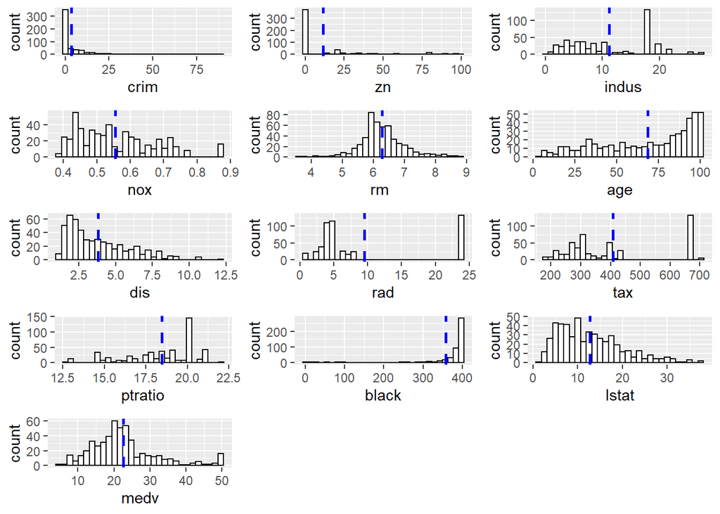

```r
library(ggplot2)
library(gridExtra)
p1 <- ggplot(Boston, aes(x=crim)) +
  geom_histogram(color="black", fill="white") +
  geom_vline(aes(xintercept=mean(crim)),
            color="blue", linetype="dashed", size=1)
p2 <- ggplot(Boston, aes(x=zn)) +
  geom_histogram(color="black", fill="white") +
  geom_vline(aes(xintercept=mean(zn)),
            color="blue", linetype="dashed", size=1)
p3 <- ggplot(Boston, aes(x=indus)) +
  geom_histogram(color="black", fill="white") +
  geom_vline(aes(xintercept=mean(indus)),
            color="blue", linetype="dashed", size=1)
p4 <- ggplot(Boston, aes(x=nox)) +
  geom_histogram(color="black", fill="white") +
  geom_vline(aes(xintercept=mean(nox)),
            color="blue", linetype="dashed", size=1)
p5 <- ggplot(Boston, aes(x=rm)) +
  geom_histogram(color="black", fill="white") +
  geom_vline(aes(xintercept=mean(rm)),
            color="blue", linetype="dashed", size=1)
p6 <- ggplot(Boston, aes(x=age)) +
  geom_histogram(color="black", fill="white") +
  geom_vline(aes(xintercept=mean(age)),
            color="blue", linetype="dashed", size=1)
p7 <- ggplot(Boston, aes(x=dis)) +
  geom_histogram(color="black", fill="white") +
  geom_vline(aes(xintercept=mean(dis)),
            color="blue", linetype="dashed", size=1)
p8 <- ggplot(Boston, aes(x=rad)) +
  geom_histogram(color="black", fill="white") +
  geom_vline(aes(xintercept=mean(rad)),
            color="blue", linetype="dashed", size=1)
p9 <- ggplot(Boston, aes(x=tax)) +
  geom_histogram(color="black", fill="white") +
  geom_vline(aes(xintercept=mean(tax)),
            color="blue", linetype="dashed", size=1)
p10 <- ggplot(Boston, aes(x=ptratio)) +
  geom_histogram(color="black", fill="white") +
  geom_vline(aes(xintercept=mean(ptratio)),
            color="blue", linetype="dashed", size=1)
p11 <- ggplot(Boston, aes(x=black)) +
  geom_histogram(color="black", fill="white") +
  geom_vline(aes(xintercept=mean(black)),
            color="blue", linetype="dashed", size=1)
p12 <- ggplot(Boston, aes(x=lstat)) +
  geom_histogram(color="black", fill="white") +
  geom_vline(aes(xintercept=mean(lstat)),
            color="blue", linetype="dashed", size=1)
p13 <- ggplot(Boston, aes(x=medv)) +
  geom_histogram(color="black", fill="white") +
  geom_vline(aes(xintercept=mean(medv)),
            color="blue", linetype="dashed", size=1)
grid.arrange(p1,p2,p3,p4,p5,p6,p7,p8,p9,p10,p11,p12,p13, nrow=5, ncol=3)
```

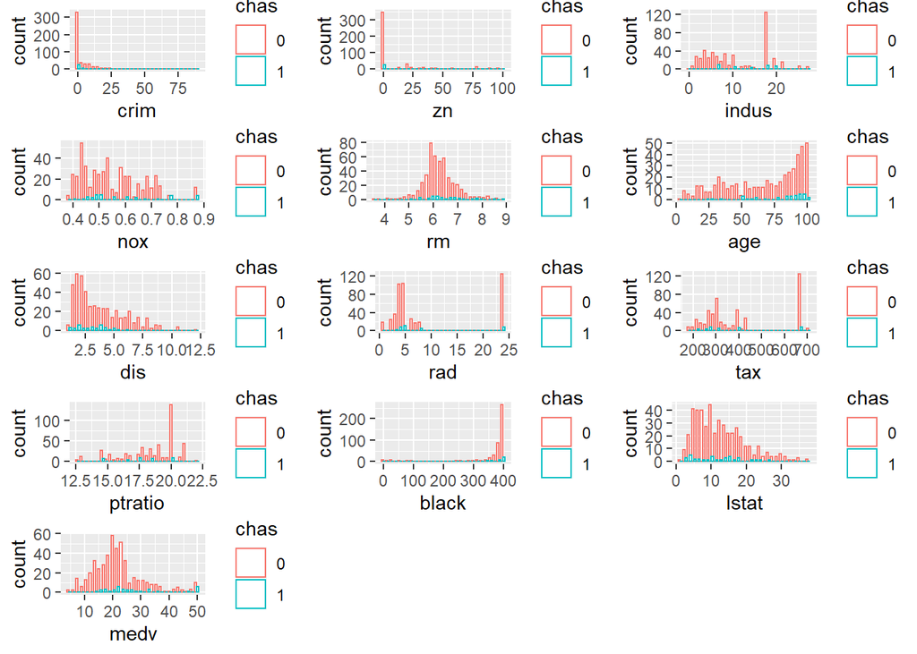

```r
g1 <- ggplot(Boston, aes(x=crim, color=chas)) +
  geom_histogram(fill="white", position="dodge")
g2 <- ggplot(Boston, aes(x=zn, color=chas)) +
  geom_histogram(fill="white", position="dodge")
g3 <- ggplot(Boston, aes(x=indus, color=chas)) +
  geom_histogram(fill="white", position="dodge")
g4 <- ggplot(Boston, aes(x=nox, color=chas)) +
  geom_histogram(fill="white", position="dodge")
g5 <- ggplot(Boston, aes(x=rm, color=chas)) +
  geom_histogram(fill="white", position="dodge")
g6 <- ggplot(Boston, aes(x=age, color=chas)) +
  geom_histogram(fill="white", position="dodge")
g7 <- ggplot(Boston, aes(x=dis, color=chas)) +
  geom_histogram(fill="white", position="dodge")
g8 <- ggplot(Boston, aes(x=rad, color=chas)) +
  geom_histogram(fill="white", position="dodge")
g9 <- ggplot(Boston, aes(x=tax, color=chas)) +
  geom_histogram(fill="white", position="dodge")
g10 <- ggplot(Boston, aes(x=ptratio, color=chas)) +
  geom_histogram(fill="white", position="dodge")
g11 <- ggplot(Boston, aes(x=black, color=chas)) +
  geom_histogram(fill="white", position="dodge")
g12 <- ggplot(Boston, aes(x=lstat, color=chas)) +
  geom_histogram(fill="white", position="dodge")
g13 <- ggplot(Boston, aes(x=medv, color=chas)) +
  geom_histogram(fill="white", position="dodge")
grid.arrange(g1,g2,g3,g4,g5,g6,g7,g8,g9,g10,g11,g12,g13, nrow=5, ncol=3)
```

## 2. Fit a linear regression model with the response variable, MEDV.

## 3. Which variables are relevant to explain MEDV? Give an answer.

```r
fit1 <- lm(medv ~ . , data = Boston)
summary(fit1)
```

```
##
## Call:
## lm(formula = medv ~ ., data = Boston)
##
## Residuals:
##     Min      1Q  Median      3Q     Max
## -15.595  -2.730  -0.518   1.777  26.199
##
## Coefficients:
##               Estimate Std. Error t value Pr(>|t|)
## (Intercept)  3.646e+01  5.103e+00   7.144 3.28e-12 ***
## crim        -1.080e-01  3.286e-02  -3.287 0.001087 **
## zn           4.642e-02  1.373e-02   3.382 0.000778 ***
## indus        2.056e-02  6.150e-02   0.334 0.738288
## chas1        2.687e+00  8.616e-01   3.118 0.001925 **
## nox         -1.777e+01  3.820e+00  -4.651 4.25e-06 ***
## rm           3.810e+00  4.179e-01   9.116  < 2e-16 ***
## age          6.922e-04  1.321e-02   0.052 0.958229
## dis         -1.476e+00  1.995e-01  -7.398 6.01e-13 ***
## rad          3.060e-01  6.635e-02   4.613 5.07e-06 ***
## tax         -1.233e-02  3.760e-03  -3.280 0.001112 **
## ptratio     -9.527e-01  1.308e-01  -7.283 1.31e-12 ***
## black        9.312e-03  2.686e-03   3.467 0.000573 ***
## lstat       -5.248e-01  5.072e-02 -10.347  < 2e-16 ***
## ---
## Signif. codes:  0 '***' 0.001 '**' 0.01 '*' 0.05 '.' 0.1 ' ' 1
##
## Residual standard error: 4.745 on 492 degrees of freedom
## Multiple R-squared:  0.7406, Adjusted R-squared:  0.7338
## F-statistic: 108.1 on 13 and 492 DF,  p-value: < 2.2e-16
```

#### Refer to the fitted multiple linear regression model, variable ‘indus’ and ‘age’ are not significant with ‘medv’. Other variables are relevant to explain ‘medv’.

## 4. Verify if the assumptions on the error are satisfied.

#### For multiple regression model, we have to check normality, constant variance, linearity and independence of residuals.

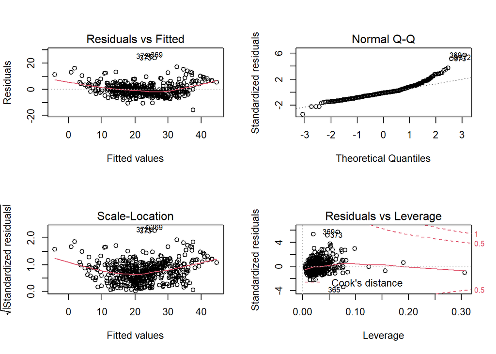

```r
par(mfrow=c(2,2))
plot(fit1)
```

```r
par(mfrow=c(1,1))
```

#### In these plots, some outliers(365, 372, 373, 369) are detected. And it seems that normality, linearity and constant variance are violated. Let’s test about normality and independence.

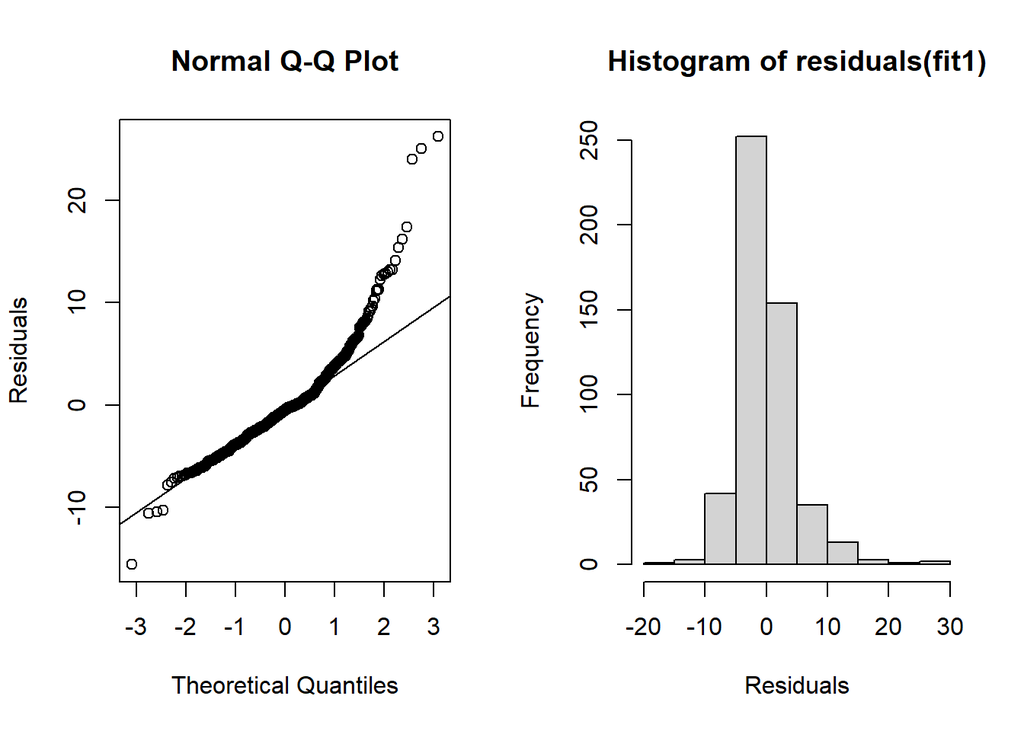

```r
par(mfrow=c(1,2))
qqnorm(residuals(fit1),ylab="Residuals")
qqline(residuals(fit1))
hist(residuals(fit1),xlab="Residuals")
```

```r
par(mfrow=c(1,1))
shapiro.test(residuals(fit1))
```

```
##
##  Shapiro-Wilk normality test
##
## data:  residuals(fit1)
## W = 0.90138, p-value < 2.2e-16
```

#### Refer to the Shapiro-Wilk normality test, p-value is lower than 2.2*10^(-16). So residuals are statistically not normality.

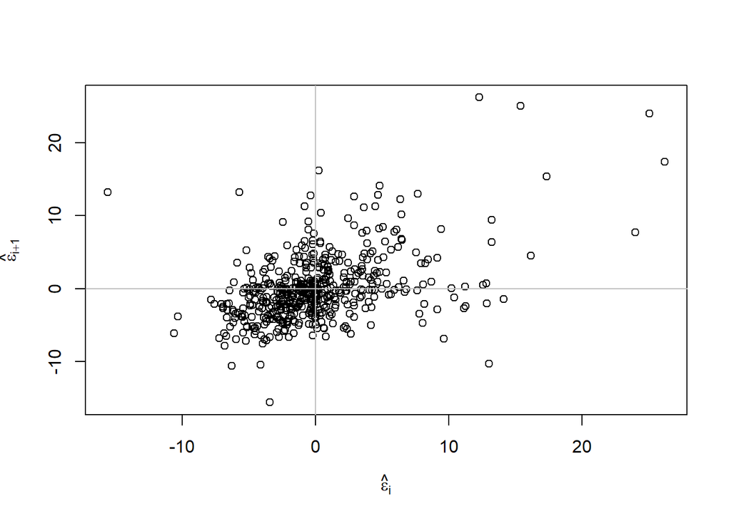

```r
n <- length(residuals(fit1))
plot(tail(residuals(fit1),n-1) ~ head(residuals(fit1),n-1), xlab= expression(hat(epsilon)[i]),ylab=expression(hat(epsilon)[i+1]))
abline(h=0,v=0,col=grey(0.75))
```

```r
library(lmtest)
dwtest(medv ~ . , data=Boston)
```

```
##
##  Durbin-Watson test
##
## data:  medv ~ .
## DW = 1.0784, p-value < 2.2e-16
## alternative hypothesis: true autocorrelation is greater than 0
```

#### Refer to the Durbin-Watson test, p-value is lower than 2.2*10^(-16). So residuals have statistically positive autocorrelation.

## 5. If some assumptions are violated, how can you remedy them?

#### To remedy them, we can do transformation(log, square, cubic etc.) about some variables or fit polynomial regression model.

## 6. Check if there exists multicollinearity.

#### For checking multicollinearity, calculate variance inflation factor(VIF).

```r
library(car)
vif(fit1)
```

```
##     crim       zn    indus     chas      nox       rm      age      dis
## 1.792192 2.298758 3.991596 1.073995 4.393720 1.933744 3.100826 3.955945
##      rad      tax  ptratio    black    lstat
## 7.484496 9.008554 1.799084 1.348521 2.941491
```

#### Refer to the result, all variables has VIF which is lower than 10. Hence it seems that multicollinearity is not exist.

## 7. Fit an additive model which can reflect some non-linear association between the response and the predictors. Describe and interpret the results.

#### I think variables ‘chas’ and ‘rad’ are not non-linearity relationship with ‘medv’. So I fitted GAM model as shown below.

```r
library(ggGam)
library(mgcv)
Boston$chas <- as.numeric(Boston$chas)
fit2 <- gam(medv ~ s(crim)+s(zn)+s(indus)+chas+s(nox)+s(rm)+s(age)+s(dis)+rad+s(tax)+s(ptratio)+s(black)+s(lstat),data=Boston)
ggGam(fit2)
```

```
##  chr "ggGam(model = fit2)"
## List of 1
##  $ model: chr "fit2"
```

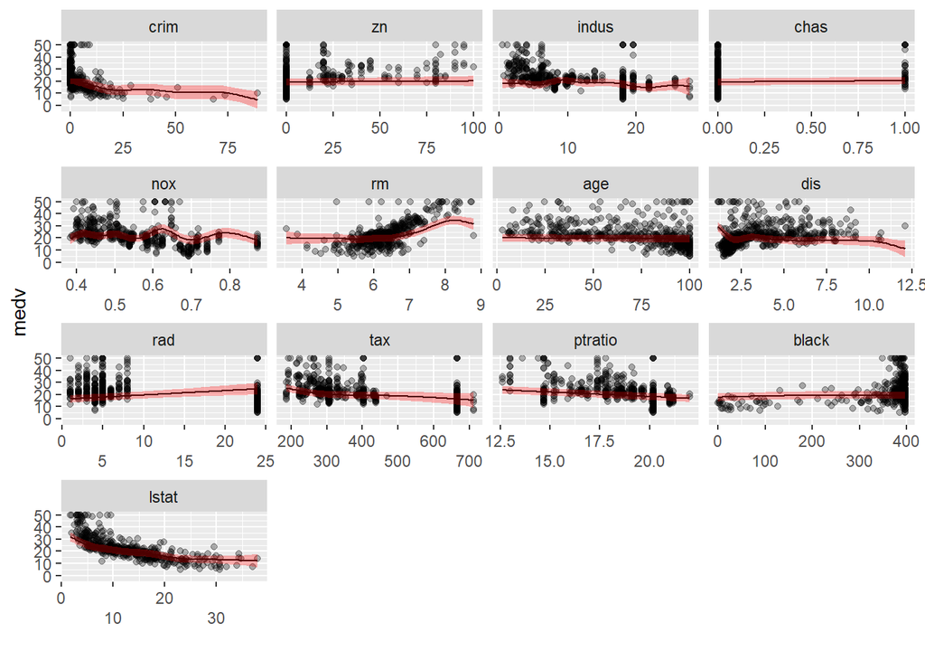

#### Refer to the plots, variables ‘crim’, ‘nox’, ‘rm’, dis’, ‘lstat’ have non-linearity relationship with ‘medv’.

```r
summary(fit2)
```

```
##
## Family: gaussian
## Link function: identity
##
## Formula:
## medv ~ s(crim) + s(zn) + s(indus) + chas + s(nox) + s(rm) + s(age) +
##     s(dis) + rad + s(tax) + s(ptratio) + s(black) + s(lstat)
##
## Parametric coefficients:
##             Estimate Std. Error t value Pr(>|t|)
## (Intercept)  19.0006     1.0842  17.525  < 2e-16 ***
## chas          1.0601     0.6183   1.715  0.08709 .
## rad           0.3622     0.1126   3.218  0.00139 **
## ---
## Signif. codes:  0 '***' 0.001 '**' 0.01 '*' 0.05 '.' 0.1 ' ' 1
##
## Approximate significance of smooth terms:
##              edf Ref.df      F p-value
## s(crim)    5.546  6.645  9.162 < 2e-16 ***
## s(zn)      1.000  1.000  0.361   0.548
## s(indus)   7.697  8.492  4.208 5.3e-05 ***
## s(nox)     9.000  9.000 17.942 < 2e-16 ***
## s(rm)      7.803  8.624 26.608 < 2e-16 ***
## s(age)     1.000  1.000  0.531   0.466
## s(dis)     8.752  8.980  8.070 < 2e-16 ***
## s(tax)     3.639  4.396 10.425 < 2e-16 ***
## s(ptratio) 1.000  1.000 37.106 < 2e-16 ***
## s(black)   1.824  2.259  1.772   0.167
## s(lstat)   7.036  8.110 24.617 < 2e-16 ***
## ---
## Signif. codes:  0 '***' 0.001 '**' 0.01 '*' 0.05 '.' 0.1 ' ' 1
##
## R-sq.(adj) =  0.886   Deviance explained = 89.8%
## GCV = 10.911  Scale est. = 9.6755    n = 506
```

#### Refer to the result, variables ‘zn’, ‘age’, ‘black’ are not significant effect. But this GAM model has adjusted R-square 0.886. So compare with multiple linear regression model (adjusted R-square 0.734), GAM model has good explainable power than multiple linear regression model.